# Escalamiento multidimensional

#### Por Camilo A. Aguilar L.

El Escalamiento Multidimensional es una técnica de análisis multivariante que, partiendo de una matriz de distancias (o bien de similitudes) entre individuos, produce una representación de los individuos en una escala euclidea ordinaria de modo que las distancias en dicha escala se aproximen lo mejor posible a las distancias de partida.

En ocasiones la información disponible es una medida de distancia o de discrepancia o diferencia entre individuos, mientras que en otras se dispone de una medida de similitud entre individuos. Se va a proporcionar una solución común tanto si los datos de partida son distancias como si son similitudes, pues de hecho será posible transformar una medida de similitud en una medida de distancia.

En el presente **notebook** utilizaremos información de distancias en carretera y avión, entre 7 diferentes ciudades de Colombia, con el propósito de evaluar cuál de dichas medidas se asemeja más a las ubicaciones reales entre las ciudades dadas. Los datos se encuentran contenidos en el siguiente [enlace](http://es.distancias.himmera.com/distancia_entre_ciudades-colombia_mapas_carreteras)

```r
ciudades <- c("Pereira", "Cucuta", "Villavicencio", "Cali", "Pasto", "Tunja", "Ipiales")
D <- matrix(0,length(ciudades),length(ciudades))
D[1, 2:7] <- c(761, 416, 209, 588, 467, 671)
D[2, 3:7] <- c(753, 976, 1330, 416, 1418)#
D[3, 4:7] <- c(561, 821, 263, 1018)
D[4, 5:7] <- c(388, 611, 475)
D[5, 6:7] <- c(912, 82)
D[6, 7:7] <- c(1057)

D <- D+t(D)
colnames(D) <- ciudades
rownames(D) <- ciudades

D
```

|  | Pereira | Cucuta | Villavicencio | Cali | Pasto | Tunja | Ipiales |
| --- | --- | --- | --- | --- | --- | --- | --- |
| Pereira | 0 | 761 | 416 | 209 | 588 | 467 | 671 |
| Cucuta | 761 | 0 | 753 | 976 | 1330 | 416 | 1418 |
| Villavicencio | 416 | 753 | 0 | 561 | 821 | 263 | 1018 |
| Cali | 209 | 976 | 561 | 0 | 388 | 611 | 475 |
| Pasto | 588 | 1330 | 821 | 388 | 0 | 912 | 82 |
| Tunja | 467 | 416 | 263 | 611 | 912 | 0 | 1057 |
| Ipiales | 671 | 1418 | 1018 | 475 | 82 | 1057 | 0 |

### Escalamiento para distancias por carretera

El siguiente algoritmo realiza el escalamiento multidimensional de la matriz de distancias para las 7 ciudades.

```r
### Multi-Dimensional Scaling
n <- length(ciudades)
uno <- matrix(1,n,1)
I <- diag(n)

J <- I - (uno%*%t(uno))/n

B <- - J%*%D^2%*%J/2

eigen.B <- eigen(B, symmetric=TRUE)

E <- eigen.B$vectors[,1:2]
L <- matrix(0,2,2)
diag(L) <- eigen.B$values[1:2]

X <- E%*%sqrt(L)
rownames(X) <- ciudades
```

Obteniendo el siguiente resultado gráfico

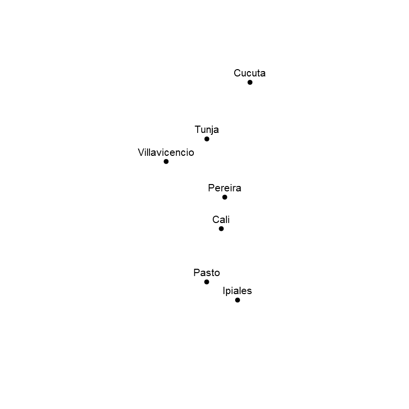

```r
mm <- max(abs(X))
plot(X[,2], -X[,1], pch=16, ann = FALSE, bty="n",
     xaxt="n",yaxt="n",
     ylim=c(-mm,mm)*1.2, xlim=c(-mm,mm)*1.2, asp=1)
text(X[,2], -X[,1], ciudades, pos=3)
```

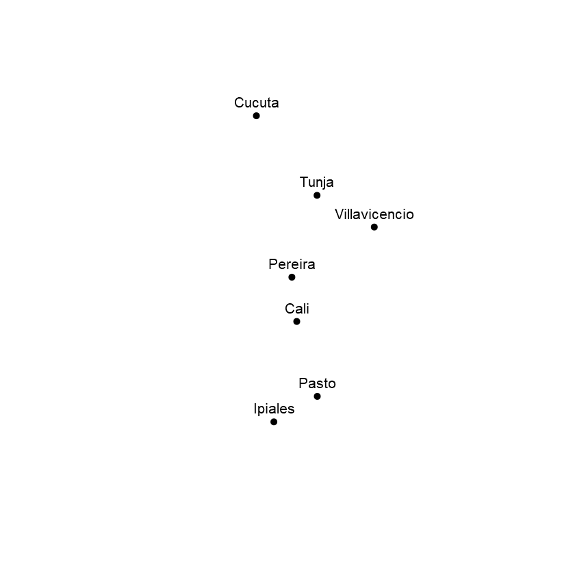

```r
### Multi-Dimensional Scaling
n <- length(ciudades)
uno <- matrix(1,n,1)
I <- diag(n)

J <- I - (uno%*%t(uno))/n

B <- - J%*%D^2%*%J/2

eigen.B <- eigen(B, symmetric=TRUE)

E <- eigen.B$vectors[,1:2]
L <- matrix(0,2,2)
diag(L) <- eigen.B$values[1:2]

X <- E%*%sqrt(L)
rownames(X) <- ciudades

## Gráfico del escalamiento
mm <- max(abs(X))
plot(-X[,2], -X[,1], pch=16, ann = FALSE, bty="n",
     xaxt="n",yaxt="n",
     ylim=c(-mm,mm)*1.2, xlim=c(-mm,mm)*1.2, asp=1)
text(-X[,2], -X[,1], ciudades, pos=3)
```